# CPR Study: Statistical Analysis (Run 14)

```r
library(tidyverse)
library(caret)
library(glmnet)
library(dplyr)
library(ROCR)
library(pROC)
library(Metrics)
library(corrplot)
```

## Data Preprocessing

- Load data
- Handle `TKT`
- Create Interaction Terms
- Manually assigning categorical variable types
- Reset reference variables(levels) for dummy variables
- Define `SMSB` (SMS Binary variable): 1 for 128 and 516, 0 for 515
- Define some new interactions (02/15/2021)
- Finally form `shell_data`

```r
data_file = "Master_TCAD_Final_20210109_shell_assumed less severe acc_recover_rev.csv"
data_shell_subset <- read.csv(data_file)

# Handle TKT
data_shell_subset <- data_shell_subset %>%
  mutate(TKT = replace(TKT, (Is.TSP.Assumed==1) + (Is.CDR.Assumed==1) +
                         (Is.FCI.assumed==1) > 0, 2))

# Create Interaction Terms
data_shell_subset <- data_shell_subset %>%
  mutate(TSP_IOF = TSP * IOF) %>%
  mutate(IOF_IOFB = IOF * IOFB) %>%
  mutate(TCL_TCLB = TCL * TCLB) %>%
  mutate(TCLsubFCI = TCL - FCI) %>%
  mutate(TSP_CDR = TSP * CDR) %>%
  mutate(TSPC_CDR = TSPC * CDR) %>%
  mutate(EIS_CDR = EIS.N * CDR)

# Manually assigning categorical variable types
cat_vars = c("JKT", "TKT", "ACT", "HMS", "SMS",
             "THT", "TFP", "TFN", "TFPB",
             "IOFB", "TCLB")
data_shell_subset[, cat_vars] = lapply(data_shell_subset[, cat_vars],
                                          factor)

# Reset reference variables(levels) for dummy variables
data_shell_subset <- data_shell_subset %>%
  mutate(JKT = relevel(JKT, ref="0")) %>%
  mutate(ACT = relevel(ACT, ref="1")) %>%
  mutate(THT = relevel(THT, ref="0")) %>%
  mutate(SMS = relevel(SMS, ref="515")) %>%
  mutate(TFP = relevel(TFP, ref="U")) %>%
  mutate(TFN = relevel(TFN, ref="1")) %>%
  mutate(HMS = relevel(HMS, ref="515")) %>%
  mutate(TFPB = relevel(TFPB, ref="0"))

# Define `SMSB` (SMS Binary variable): 1 for 128 and 516, 0 for 515
data_shell_subset <- data_shell_subset %>%
  mutate(SMSB = ifelse(SMS == '515', 0, 1))

# New interactions defined on 02/15/2021
data_shell_subset <- data_shell_subset %>%
  mutate(TSPS = TSP * TSP) %>%
  mutate(EISS = EIS.N * EIS.N) %>%
  mutate(TSPS_CDR = TSPS * CDR) %>%
  mutate(EIS_IOF = EIS.N * IOF) %>%
  mutate(TSPS_IOF = TSPS * IOF) %>%
  mutate(TSPC_IOF = TSPC * IOF) %>%
  mutate(EISS_IOF = EISS * IOF) %>%
  mutate(EISS_CDR = EISS * CDR)
```

- Check for Missing Values in TKT? No missing values.

```r
data_shell_subset$TKT[is.na(data_shell_subset$TKT)]=1
sum(is.na(data_shell_subset$TKT))
```

[output not shown]

- Construct the data set for shell analysis `shell_data`. Further split into training data `train_shell` (80%) and testing data `test_shell` (20%)

```r
var_names <- c("TSPS", "EISS", "TSP_CDR", "TSPS_CDR", "EIS_IOF", "TSP",
               "CDR", "JKT", "IOF", "TSP_IOF", "EIS.N", "TWT", "TKT",
               "ACT", "STS", "SID", "THT", "EIS_CDR", "Z.indicator", "LDLS")
shell_data <- data_shell_subset %>%
  filter(SUBS==1) %>%
  select(all_of(var_names))

set.seed(1231)

train_id <- shell_data$LDLS %>%
  createDataPartition(p=0.8,list=FALSE)
train_shell <- shell_data[train_id, ]
test_shell <- shell_data[-train_id, ]
```

## Lasso

```r
shell_x <- model.matrix(LDLS ~ ., data = train_shell)[,-1]
shell_y <- train_shell$LDLS

shell_cv.lasso <- cv.glmnet(shell_x, shell_y, alpha = 1, family = "binomial")
small.lambda.min.betas <- coef(shell_cv.lasso, s = "lambda.min")
small.lambda.1se.betas <- coef(shell_cv.lasso, s = "lambda.1se")
```

```r
round(cbind(small.lambda.min.betas,
                  small.lambda.1se.betas), dig = 4)
```

```
20 x 2 sparse Matrix of class "dgCMatrix"
                  1       1
(Intercept)  1.4579 -3.2585
TSPS        -0.0001  .
EISS        -0.0006  .
TSP_CDR      .       .
TSPS_CDR     0.0000  .
EIS_IOF      0.0045  0.0011
TSP          0.0267  0.0237
CDR          0.0398  0.0166
JKT1        -0.5262 -0.4986
IOF          0.1547  0.1298
TSP_IOF     -0.0033  0.0006
EIS.N        0.0649  .
TWT          0.0001  0.0000
TKT2        -0.3151 -0.7961
ACT2         0.1174  .
STS         -6.3912 -1.1282
SID         -0.0279  .
THT1        -0.4273  .
EIS_CDR     -0.0013  .
Z.indicator -1.6633 -0.5621
```

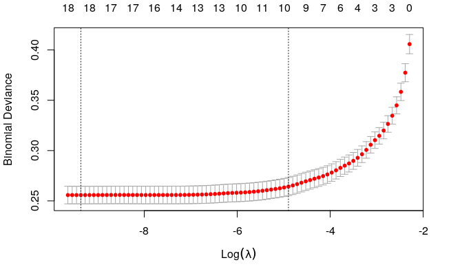

```r
plot(shell_cv.lasso)
```

## CV-Lasso

Repeatedly (`m = 10` times) apply `glmnet` with Lasso on a subset (80%) of the data, record the corresponding coefficients in two matrices and then report the mean and frequency (of being non-zero).

```r
m = 10 # Number of iterations
ncoefs_min = NULL  # coefs with lambda_min
ncoefs_1se = NULL  # coefs with lambda_1se
shell_x <- model.matrix(LDLS ~ ., data = shell_data)[,-1]
shell_y <- shell_data$LDLS

for(i in 1:m){
  tmp_id = shell_data$LDLS %>%
    createDataPartition(p=0.8, list=FALSE)
  tmp_x <- shell_x[tmp_id, ]
  tmp_y <- shell_y[tmp_id]

  tmp_cv.lasso <- cv.glmnet(tmp_x, tmp_y,
                              alpha = 1, family = "binomial")

  small.lambda.min.betas <- coef(tmp_cv.lasso, s = "lambda.min")
  small.lambda.1se.betas <- coef(tmp_cv.lasso, s = "lambda.1se")

  ncoefs_min=cbind(ncoefs_min, small.lambda.min.betas)
  ncoefs_1se=cbind(ncoefs_1se, small.lambda.1se.betas)
}

colnames(ncoefs_min) = NULL
colnames(ncoefs_1se) = NULL

avgcoefs <- data.frame(
  ave_min = rowMeans(ncoefs_min),
  freq_min = rowMeans(ncoefs_min != 0),
  ave_1se = rowMeans(ncoefs_1se),
  freq_1se = rowMeans(ncoefs_1se != 0))
```

- `ncoefs_min`: coefficinet vectors over 10 iterations with `lambda.min`

```r
round(ncoefs_min, dig = 2)
```

```
20 x 10 sparse Matrix of class "dgCMatrix"

(Intercept)  2.25  1.49  2.69  1.05  1.07  1.32  1.93  1.49  1.39  1.20
TSPS         0.00  .     .     .     0.00  .     .     0.00  .     .
EISS         .     0.00  0.00  0.00  0.00  0.00  0.00  .     .     0.00
TSP_CDR      .     .     0.00  .     .     .     .     .     .     .
TSPS_CDR     0.00  0.00  0.00  0.00  .     .     .     .     .     0.00
EIS_IOF      0.00  0.00  0.00  0.00  0.00  0.00  0.00  0.00  0.00  0.00
TSP          0.03  0.01  0.01  0.01  0.00  0.02  0.02  0.02  0.02  0.01
CDR          0.04  0.05  0.04  0.04  0.05  0.05  0.05  0.04  0.05  0.04
JKT1        -0.57 -0.46 -0.56 -0.30 -0.47 -0.34 -0.57 -0.53 -0.56 -0.46
IOF          0.13  0.09  0.11  0.15  0.12  0.13  0.10  0.13  0.09  0.14
TSP_IOF      .     .     .     .     .     .     .     .     .     .
EIS.N        0.03  0.07  0.06  0.06  0.05  0.06  0.04  0.03  0.03  0.07
TWT          0.00  0.00  0.00  0.00  0.00  0.00  0.00  0.00  0.00  0.00
TKT2        -0.50 -0.48 -0.52 -0.57 -0.59 -0.39 -0.45 -0.79 -0.55 -0.62
ACT2         0.37  0.24  0.13  0.12  0.17  0.34  0.30  0.27  0.23  0.46
STS         -6.22 -6.04 -6.32 -6.11 -6.05 -6.44 -6.88 -4.88 -5.82 -5.29
SID         -0.03 -0.03 -0.04 -0.02 -0.02 -0.03 -0.03 -0.03 -0.03 -0.03
THT1        -0.41 -0.34 -0.42 -0.48 -0.38 -0.58 -0.39 -0.39 -0.39 -0.36
EIS_CDR      0.00  0.00  0.00  0.00  0.00  0.00  0.00  0.00  0.00  0.00
Z.indicator -1.54 -1.58 -1.59 -1.39 -1.52 -1.47 -1.44 -1.23 -1.43 -1.67
```

- `ncoefs_1se`: coefficinet vectors over 10 iterations with `lambda.1se`

```r
round(ncoefs_1se, dig = 2)
```

```
20 x 10 sparse Matrix of class "dgCMatrix"

(Intercept) -3.02 -3.16 -2.85 -3.50 -3.32 -3.59 -2.79 -3.19 -3.43 -3.40
TSPS         .     .     .     .     .     .     .     .     .     .
EISS         .     .     .     .     .     .     .     .     .     .
TSP_CDR      .     .     .     .     .     .     .     .     .     .
TSPS_CDR     .     .     .     .     .     .     .     .     .     .
EIS_IOF      0.00  0.00  0.00  0.00  0.00  0.00  0.00  0.00  0.00  .
TSP          0.02  0.02  0.02  0.01  0.01  0.02  0.02  0.01  0.02  0.01
CDR          0.02  0.02  0.02  0.02  0.02  0.02  0.02  0.02  0.02  0.02
JKT1        -0.49 -0.38 -0.47 -0.29 -0.41 -0.39 -0.51 -0.44 -0.45 -0.33
IOF          0.14  0.14  0.12  0.10  0.14  0.15  0.15  0.11  0.10  0.11
TSP_IOF      0.00  0.00  0.00  0.00  0.00  0.00  0.00  0.00  0.00  0.00
EIS.N        0.00  0.01  0.00  0.01  0.01  0.00  0.01  .     .     0.00
TWT          0.00  0.00  0.00  0.00  0.00  0.00  0.00  0.00  0.00  0.00
TKT2        -0.91 -0.90 -0.99 -1.08 -1.01 -0.88 -0.81 -1.25 -0.99 -1.10
ACT2         .     .     .     .     .     .     .     .     .     .
STS         -1.51 -1.71 -1.47 -0.64 -1.16 -0.92 -2.03 -0.44 -0.45 -0.49
SID          .     .     0.00  .     .     .     .     .     .     .
THT1         .     .     .     .     .     .     .     .     .     .
EIS_CDR      .     .     .     .     .     .     .     .     .     .
Z.indicator -0.65 -0.65 -0.55 -0.30 -0.53 -0.47 -0.69 -0.26 -0.39 -0.46
```

- `avgcoefs`: averaage and selection rate (over 10 iterations) for `ncoefs_min` and `ncoefs_1se`, respectively.

```r
round(as.matrix(avgcoefs), dig = 3)
```

```
            ave_min freq_min ave_1se freq_1se
(Intercept)   1.588      1.0  -3.227      1.0
TSPS          0.000      0.3   0.000      0.0
EISS          0.000      0.7   0.000      0.0
TSP_CDR       0.000      0.1   0.000      0.0
TSPS_CDR      0.000      0.5   0.000      0.0
EIS_IOF       0.001      1.0   0.001      0.9
TSP           0.013      1.0   0.018      1.0
CDR           0.047      1.0   0.021      1.0
JKT1         -0.482      1.0  -0.415      1.0
IOF           0.119      1.0   0.126      1.0
TSP_IOF       0.000      0.0   0.001      1.0
EIS.N         0.051      1.0   0.005      0.8
TWT           0.000      1.0   0.000      1.0
TKT2         -0.546      1.0  -0.992      1.0
ACT2          0.264      1.0   0.000      0.0
STS          -6.007      1.0  -1.082      1.0
SID          -0.028      1.0   0.000      0.1
THT1         -0.413      1.0   0.000      0.0
EIS_CDR      -0.001      1.0   0.000      0.0
Z.indicator  -1.486      1.0  -0.495      1.0
```

## Correlation

```r
shell_cor <- cor(shell_x)
upper_shell <- round(shell_cor, dig = 2)
upper_shell[upper.tri(upper_shell, diag = TRUE)] <- ''
as.data.frame(upper_shell)
```

|  | TSPS | EISS | TSP_CDR | TSPS_CDR | EIS_IOF | TSP | CDR | JKT1 | IOF | TSP_IOF | EIS.N | TWT | TKT2 | ACT2 | STS | SID | THT1 | EIS_CDR | Z.indicator |
| --- | --- | --- | --- | --- | --- | --- | --- | --- | --- | --- | --- | --- | --- | --- | --- | --- | --- | --- | --- |
| TSPS |  |  |  |  |  |  |  |  |  |  |  |  |  |  |  |  |  |  |  |
| EISS | 0.81 |  |  |  |  |  |  |  |  |  |  |  |  |  |  |  |  |  |  |
| TSP_CDR | 0.89 | 0.78 |  |  |  |  |  |  |  |  |  |  |  |  |  |  |  |  |  |
| TSPS_CDR | 0.86 | 0.77 | 0.98 |  |  |  |  |  |  |  |  |  |  |  |  |  |  |  |  |
| EIS_IOF | 0.86 | 0.85 | 0.85 | 0.79 |  |  |  |  |  |  |  |  |  |  |  |  |  |  |  |
| TSP | 0.95 | 0.76 | 0.81 | 0.75 | 0.84 |  |  |  |  |  |  |  |  |  |  |  |  |  |  |
| CDR | 0.79 | 0.7 | 0.94 | 0.87 | 0.82 | 0.76 |  |  |  |  |  |  |  |  |  |  |  |  |  |
| JKT1 | -0.19 | -0.19 | -0.21 | -0.2 | -0.21 | -0.18 | -0.21 |  |  |  |  |  |  |  |  |  |  |  |  |
| IOF | 0.63 | 0.46 | 0.65 | 0.55 | 0.78 | 0.66 | 0.77 | -0.17 |  |  |  |  |  |  |  |  |  |  |  |
| TSP_IOF | 0.9 | 0.7 | 0.86 | 0.79 | 0.93 | 0.89 | 0.84 | -0.19 | 0.85 |  |  |  |  |  |  |  |  |  |  |

[output cut: 9 more lines]

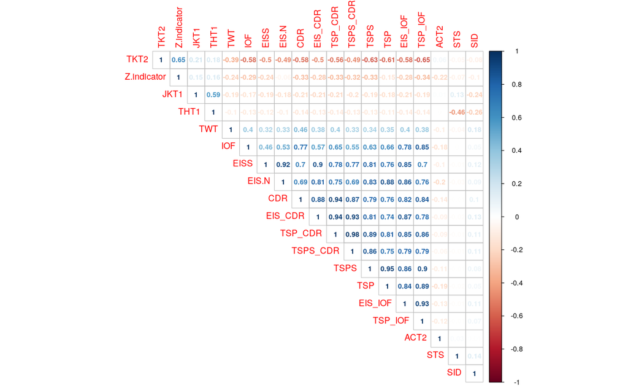

```r
corrplot(shell_cor, type="upper",
         order="hclust",
         method="number", number.cex = 0.8)
```

## Model Evaluation

- Fit a logistic model with selected variables on all training data `train_shell`.

```r
shell_sel_vars <- c('TSP', 'CDR', 'JKT', 'IOF', 'TSP_IOF', 'EIS.N',
                      'TWT', 'TKT',
                      'ACT', 'STS', 'SID', 'THT', 'EIS_CDR', 'Z.indicator')
shell_data_logit <- glm(formula = LDLS ~ .,
                        family = binomial,
                        data = train_shell[, c('LDLS', shell_sel_vars)])
summary(shell_data_logit)
```

```
Call:
glm(formula = LDLS ~ ., family = binomial, data = train_shell[,
    c("LDLS", shell_sel_vars)])

Deviance Residuals:
    Min       1Q   Median       3Q      Max
-1.6589  -0.1678  -0.1102  -0.1005   3.4886

Coefficients:
              Estimate Std. Error z value Pr(>|z|)
(Intercept)  1.401e+00  1.073e+00   1.306 0.191528
TSP          1.584e-02  1.367e-02   1.158 0.246765
CDR          4.971e-02  1.131e-02   4.395 1.11e-05 ***
JKT1        -5.724e-01  1.856e-01  -3.083 0.002047 **
IOF          1.217e-01  6.848e-02   1.778 0.075475 .
TSP_IOF      8.173e-04  1.792e-03   0.456 0.648425
EIS.N        4.409e-02  1.066e-02   4.138 3.50e-05 ***
TWT          5.541e-05  1.513e-05   3.663 0.000249 ***
TKT2        -3.509e-01  2.298e-01  -1.527 0.126758
ACT2         1.325e-01  2.541e-01   0.521 0.602029
STS         -6.344e+00  1.128e+00  -5.626 1.84e-08 ***
SID         -2.578e-02  8.304e-03  -3.104 0.001908 **
THT1        -4.195e-01  1.900e-01  -2.208 0.027226 *
EIS_CDR     -1.023e-03  2.649e-04  -3.863 0.000112 ***
Z.indicator -1.514e+00  2.438e-01  -6.212 5.24e-10 ***
---
Signif. codes:  0 ‘***’ 0.001 ‘**’ 0.01 ‘*’ 0.05 ‘.’ 0.1 ‘ ’ 1

(Dispersion parameter for binomial family taken to be 1)

    Null deviance: 4039.9  on 9936  degrees of freedom
Residual deviance: 2513.1  on 9922  degrees of freedom
AIC: 2543.1

Number of Fisher Scoring iterations: 7
```

- AUC

```r
log_predict <- predict(shell_data_logit,
                       newdata = test_shell,
                       type = "response")
auc(test_shell$LDLS, log_predict)
```

```
[1] 0.9452944
```

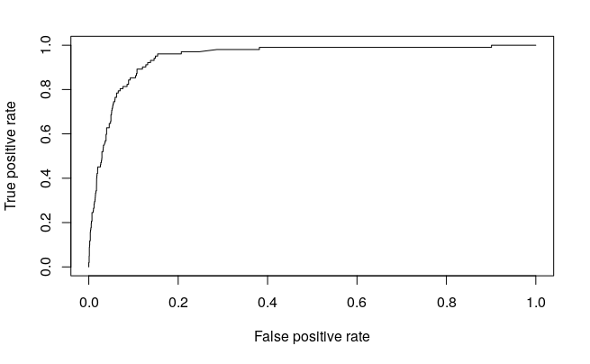

```r
pr <- prediction(log_predict, test_shell$LDLS)
perf <- performance(pr, measure="tpr", x.measure="fpr")
plot(perf)
```

- Predictive Accuracy

```r
yHat = shell_data_logit$fitted.values > 0.5
tab = table(train_shell$LDLS, yHat)
print(tab)
```

```
   yHat
    FALSE TRUE
  0  9349   75
  1   417   96
```

```r
sum(diag(tab))/sum(tab)
```

```
[1] 0.9504881
```

```r
testyHat = log_predict > 0.5
tab = table(test_shell$LDLS, testyHat)
print(tab)
```

```
   testyHat
    FALSE TRUE
  0  2368   14
  1    81   21
```

```r
sum(diag(tab))/sum(tab)
```

```
[1] 0.9617552
```

- McFadden’s Pseudo R^2? (Deviance)

```r
r2Log <- function(model) {
  summaryLog <- summary(model)
  1 - summaryLog$deviance / summaryLog$null.deviance
}
r2Log(shell_data_logit)
```

```
[1] 0.3779257
```

## Prediction

- 1. Fit a **shared** logistic model with selected variables on all shell data `shell_data`, and then form prediction on five new cars.
- 2. For each of the five test cars, fit a **separate** logistic model on a subset of the data (similar to that particular test car’s features) and form prediction.
- Note that the features used in the two approaches are slightly different. For example, in approach 2), we add features `TWT=10000` and `TKT=1`, and drop features `JKT` and `THT`.

```r
# Construct newcars data frame with features for the five test cars
newcars = data.frame(
  TSP = rep(26, 5),
  CDR = rep(11, 5),
  JKT = c('0', rep('1', 4)),
  IOF = rep(6, 5),
  TSP_IOF = rep(156, 5),
  EIS.N = rep(16.5, 5),
  ACT = rep('1', 5),
  STS = c(rep(0.4375, 3), 0.5625, 0.625),
  SID = rep(119, 5),
  THT = c('0', rep('1', 4)),
  EIS_CDR = rep(181.5, 5),
  Z.indicator = rep(0, 5),
  TWT = rep(10000, 5),
  TKT = rep('1', 5))
rownames(newcars) = c('nojacket_111', 'jacket_111', '117R', '117J', '5')

newcars_pred = data.frame(matrix(NA, nrow=5, 2))
rownames(newcars_pred) = rownames(newcars)
colnames(newcars_pred) = c("Shared_Model", "Separate_Models")

# 1) Fit one shared model
shell_lasso_vars <- c('TSP', 'CDR', 'JKT', 'IOF', 'TSP_IOF', 'EIS.N',
                      # 'TWT', 'TKT',
                      'ACT', 'STS', 'SID', 'THT', 'EIS_CDR', 'Z.indicator')
shell_data_logit <- glm(formula = LDLS ~ .,
                        family = binomial,
                        data = shell_data[, c('LDLS', shell_lasso_vars)])
newcars_pred[, 1] <- predict(shell_data_logit, newcars, type="response")

# 2) Fit five separate models

car1_subset <- shell_data %>% filter(JKT=="0" & THT=="0")
car2_subset <- shell_data %>% filter(JKT=="1" & THT=="1")
car3_subset <- shell_data %>% filter(JKT=="1" & STS < 0.5 & THT=="1")
car4_subset <- shell_data %>% filter(JKT=="1" & STS >= 0.5 & STS<0.6 & THT=="1")
car5_subset <- shell_data %>% filter(JKT=="1" & STS>=0.6 & THT=="0")

tmp_vars <- c('TSP', 'CDR', 'IOF', 'TSP_IOF', 'EIS.N',
              'TWT', 'TKT', 'ACT', 'EIS_CDR')
car1_logit <- glm(LDLS ~ ., family = binomial,
                  data = car1_subset[, c('LDLS', tmp_vars)])
car2_logit <- glm(LDLS ~ ., family = binomial,
                  data = car2_subset[, c('LDLS', tmp_vars)])
car3_logit <- glm(LDLS ~ ., family = binomial,
                  data = car3_subset[, c('LDLS', tmp_vars)])
car4_logit <- glm(LDLS ~ ., family = binomial,
                  data = car4_subset[, c('LDLS', tmp_vars)])
```

```
glm.fit: fitted probabilities numerically 0 or 1 occurred
```

```r
car5_logit <- glm(LDLS ~ ., family = binomial,
                  data = car5_subset[, c('LDLS', tmp_vars)])

newcars_pred[1, 2] <- predict(car1_logit, newcars[1,],   type="response")
newcars_pred[2, 2] <- predict(car2_logit, newcars[1,],   type="response")
newcars_pred[3, 2] <- predict(car3_logit, newcars[1,],   type="response")
newcars_pred[4, 2] <- predict(car4_logit, newcars[1,],   type="response")
newcars_pred[5, 2] <- predict(car5_logit, newcars[1,],   type="response")

tmp_output = data.frame(matrix(0, 5, 3))
colnames(tmp_output) = c("0", "1", "total")
rownames(tmp_output) = paste0('subset', 1:5)
for(i in 1:5)
  tmp_output[i, 1:2] = table(get(paste0('car', i, '_subset', sep=''))$LDLS)
tmp_output[,3] = tmp_output[, 1] + tmp_output[, 2]
```

- Summary of the five subsets of data

```
           0   1 total
subset1 2539 344  2883
subset2 6482 188  6670
subset3 6376 186  6562
subset4   91   2    93
subset5 1130  20  1150
```

- The two sets of predictions

```
             Shared_Model Separate_Models
nojacket_111        0.148           0.190
jacket_111          0.064           0.089
117R                0.064           0.091
117J                0.029           0.000
5                   0.020           0.010
```